# Тюменцева Арина Б22-701 Вариант 25 Лабораторная работа №2

Tyumentseva

2024-12-01

### **ОТЧËТ**

**по лабораторной работе №2 (вариант 25)**  
**по дисциплине:** «Статистика»

**Выполнил:** студент группы Б22-701  
**Тюменцева Арина Владиславовна**

**Проверил:** Смирнов Д. С.

Москва, 2024 г.

### Введение:

Дана мастер-таблица, содержащая результаты маркетингового опроса по методу идеальной точки. Респонденты характеризуются полом, возрастом и. местом прохождения опроса (ст. метро).

**Цель**: Определить и обосновать выбор метода отбора выборочной совокупности, для получения наиболее устойчивого результата опроса

#### **Ход работы:**

#### Задание 1: Установить зерно генератора случайных чисел равное 100

```r
set.seed(100)
```

#### **Задание 2: загрузить материалы индивидуального проекта**

```r
load(file= "/Users/arinatyumentseva/Desktop/3 курс/Лабораторная работа №2/Вариант25_Б22-701_Тюменцева.RData")
head(Result)
```

```
##               Код Респондента Возраст Возрастная група    Пол
## Респондент 1 a35c521937008ada      53       Pre.Senior Female
## Респондент 2 a509936b6255512e      20      Young.Adult   Male
## Респондент 3 45a5bbf42fe43a1f      23      Young.Adult   Male
## Респондент 4 eed45cf87c55524b      27      Young.Adult   Male
## Респондент 5 606177a1a977ce45      68           Senior   Male
## Респондент 6 94b8d72b14215895      50       Pre.Senior Female
##                             Станция
## Респондент 1 Рязанский проспект 226
## Респондент 2            Римская 167
## Респондент 3      Юго-Западная   19
## Респондент 4      Деловой центр 263
## Респондент 5           Говорово 143
## Респондент 6         Белорусская 91
##              Насколько по вашему мнению должен быть широкий ассортимент у маркетплейса? (1 - минимальный набор необходимых товаров, 7 - идеальный ассортимент, включающий все возможные товары и услуги) ...
## Респондент 1                                                                                                                                                                                               3
## Респондент 2                                                                                                                                                                                               5
## Респондент 3                                                                                                                                                                                               3
## Респондент 4                                                                                                                                                                                               3
## Респондент 5                                                                                                                                                                                               1
## Респондент 6                                                                                                                                                                                               4
##              Насколько по вашему мнению должен быть удобным интерфейс у маркетплейса? (1 - совершенно неудобный, 7 - идеальный интерфейс, который интуитивно понятен и прост в использовании) ...
## Респондент 1                                                                                                                                                                                    1
## Респондент 2                                                                                                                                                                                    7
## Респондент 3                                                                                                                                                                                    5
## Респондент 4                                                                                                                                                                                    3
```

[output cut: 240 more lines]

```r
names(Result)
```

```
##  [1] "Код Респондента"
##  [2] "Возраст"
##  [3] "Возрастная група"
##  [4] "Пол"
##  [5] "Станция"
##  [6] "Насколько по вашему мнению должен быть широкий ассортимент у маркетплейса? (1 - минимальный набор необходимых товаров, 7 - идеальный ассортимент, включающий все возможные товары и услуги)"
##  [7] "Насколько по вашему мнению должен быть удобным интерфейс у маркетплейса? (1 - совершенно неудобный, 7 - идеальный интерфейс, который интуитивно понятен и прост в использовании)"
##  [8] "Насколько по вашему мнению должны быть безопасными платежи на маркетплейсе? (1 - минимально безопасные, 7 - идеальная безопасность, обеспечивающая полную защиту данных пользователей)"
##  [9] "Насколько по вашему мнению должна быть развита система отзывов и рейтингов на маркетплейсе? (1 - отсутствуют отзывы и рейтинги, 7 - идеальная система, позволяющая получить полную информацию о товарах и продавцах)"
## [10] "Насколько по вашему мнению должна быть развита поддержка продавцов на маркетплейсе? (1 - минимальная поддержка, 7 - идеальная поддержка, включающая все необходимые инструменты и ресурсы для успешной торговли)"
## [11] "Насколько по вашему мнению должна быть эффективной логистика и доставка на маркетплейсе? (1 - минимально эффективная, 7 - идеальная система, обеспечивающая быструю и надежную доставку товаров)"
## [12] "Насколько вам важен широкий ассортимент у маркетплейса? (1 - совершенно не важен, 7 - крайне важен для выбора)"
## [13] "Насколько вам важен удобный интерфейс у маркетплейса? (1 - совершенно не важен, 7 - крайне важен для комфортного использования)"
## [14] "Насколько вам важна безопасность платежей на маркетплейсе? (1 - совершенно не важна, 7 - крайне важна для доверия к сервису)"
## [15] "Насколько вам важна система отзывов и рейтингов на маркетплейсе? (1 - совершенно не важна, 7 - крайне важна для принятия решения о покупке)"
```

[output cut: 26 more lines]

```r
str(Result)
```

```
## 'data.frame':    15000 obs. of  41 variables:
##  $ Код Респондента                                                                                                                                                                                                     : chr  "a35c521937008ada" "a509936b6255512e" "45a5bbf42fe43a1f" "eed45cf87c55524b"…
##  $ Возраст                                                                                                                                                                                                             : num  53 20 23 27 68 50 27 24 53 27 ...
##  $ Возрастная група                                                                                                                                                                                                    : Factor w/ 4 levels "Young.Adult",..: 3 1 1 1 4 3 1 1 3 1 ...
##  $ Пол                                                                                                                                                                                                                 : Factor w/ 2 levels "Female","Male": 1 2 2 2 2 1 2 2 2 2 ...
##  $ Станция                                                                                                                                                                                                             : chr  "Рязанский проспект 226" "Римская 167" "Юго-Западная   19" "Деловой центр 2…
##  $ Насколько по вашему мнению должен быть широкий ассортимент у маркетплейса? (1 - минимальный набор необходимых товаров, 7 - идеальный ассортимент, включающий все возможные товары и услуги)                         : int  3 5 3 3 1 4 6 5 5 3 ...
##  $ Насколько по вашему мнению должен быть удобным интерфейс у маркетплейса? (1 - совершенно неудобный, 7 - идеальный интерфейс, который интуитивно понятен и прост в использовании)                                    : int  1 7 5 3 4 3 3 3 5 5 ...
##  $ Насколько по вашему мнению должны быть безопасными платежи на маркетплейсе? (1 - минимально безопасные, 7 - идеальная безопасность, обеспечивающая полную защиту данных пользователей)                              : int  7 7 7 4 2 2 7 6 5 7 ...
##  $ Насколько по вашему мнению должна быть развита система отзывов и рейтингов на маркетплейсе? (1 - отсутствуют отзывы и рейтинги, 7 - идеальная система, позволяющая получить полную информацию о товарах и продавцах): int  1 4 4 4 3 6 4 7 2 5 ...
##  $ Насколько по вашему мнению должна быть развита поддержка продавцов на маркетплейсе? (1 - минимальная поддержка, 7 - идеальная поддержка, включающая все необходимые инструменты и ресурсы для успешной торговли)    : int  1 3 3 2 1 1 3 3 2 5 ...
##  $ Насколько по вашему мнению должна быть эффективной логистика и доставка на маркетплейсе? (1 - минимально эффективная, 7 - идеальная система, обеспечивающая быструю и надежную доставку товаров)                    : int  3 3 1 3 2 2 2 2 7 2 ...
##  $ Насколько вам важен широкий ассортимент у маркетплейса? (1 - совершенно не важен, 7 - крайне важен для выбора)                                                                                                      : int  5 1 2 2 5 2 5 2 7 1 ...
##  $ Насколько вам важен удобный интерфейс у маркетплейса? (1 - совершенно не важен, 7 - крайне важен для комфортного использования)                                                                                     : int  2 1 1 1 1 3 2 3 4 1 ...
##  $ Насколько вам важна безопасность платежей на маркетплейсе? (1 - совершенно не важна, 7 - крайне важна для доверия к сервису)                                                                                        : int  5 6 7 3 6 3 6 7 3 6 ...
```

[output cut: 27 more lines]

## Для генеральной совокупности провести расчет баллов отклонения от идеальной точки

```r
deviations <- data.frame(matrix(nrow = nrow(Result), ncol = 4))
rownames(deviations) <- rownames(Result)
marketplace_names = c('Ozon', 'Яндекс Маркет', 'Wildberries', 'Сбер Мегамаркет')
names(deviations) = marketplace_names
ideal = Result[, 6:11]
ideal_importance = Result[,12:17]
ozon = Result[, 18:23]
yandex_market = Result[, 24:29]
wildberries = Result[, 30:35]
sber_megamarket = Result[, 36:41]
for (i in 1:length(Result[,1])){
  deviations[i, 1] = sum(abs(ozon[i,] - ideal[i,]) * ideal_importance[i, ])
  deviations[i, 2] = sum(abs(yandex_market[i,] - ideal[i,]) * ideal_importance[i, ])
  deviations[i, 3] = sum(abs(wildberries[i,] - ideal[i,]) * ideal_importance[i, ])
  deviations[i, 4] = sum(abs(sber_megamarket[i,] - ideal[i,]) * ideal_importance[i, ])
}
head(deviations)
```

```
##              Ozon Яндекс Маркет Wildberries Сбер Мегамаркет
## Респондент 1   47            44          23              42
## Респондент 2   54            59          24              29
## Респондент 3   56            66          41              44
## Респондент 4   10            19          11              20
## Респондент 5   54            29          37              55
## Респондент 6   21            20          51              30
```

## Определите по генеральной совокупности бренд, обладающий наибольшим приближением к пользовательскому идеалу. Будем в дальнейшем ориентироваться на разброс данного столбца.

```r
library(DescTools)

stat <- data.frame(matrix(nrow = 5, ncol = 4))
rownames(stat) <- c("Выборочное среднее", "Медиана", "Мода", "Усеченное среднее", "Дисперсия")
names(stat) <- marketplace_names

for (i in 1:length(marketplace_names)) {
  D <- deviations[, i]

  stat[1, i] <- mean(D)
  stat[2, i] <- median(D)
  modes <- DescTools::Mode(D)
  stat[3, i] <- modes[which.min(abs(modes - median(D)))]
  stat[4, i] <- mean(D, trim = 0.05)
  stat[5, i] <- var(D)
}
head(stat)
```

```
##                         Ozon Яндекс Маркет Wildberries Сбер Мегамаркет
## Выборочное среднее  46.49660       53.4336    45.75400        45.56547
## Медиана             45.00000       52.0000    43.00000        44.00000
## Мода                46.00000       49.0000    36.00000        41.00000
## Усеченное среднее   45.96881       52.8600    44.97504        44.83430
## Дисперсия          293.79451      369.8289   361.50012       338.20533
```

Сбер Мегамаркет обладает наибольшим приближением к пользовательскому идеалу (наименьшее выборочное среднее).

## Отобрать разведочную совокупность для оценки дисперсии.

```r
dataset <- cbind(deviations, Result)
colnames(dataset)[colnames(dataset) == "Возрастная група"] <- "Возрастная_группа"
```

## Организовать отбор выборок по каждому из способов в соответствии с определённым количеством элементов. Используемый алгоритм и реализующий его код должен предполагать многократное его использование, для перепроведения отбора, при изменении объема выборки

```r
library(dplyr)
library(digest)

conflicted::conflict_prefer("filter", "dplyr")
```

```
## [conflicted] Will prefer dplyr::filter over any other package.
```

```r
random_selection_repeat <- function(dataset, sample_size) {
  sampled_data <- dataset[sample(1:nrow(dataset), sample_size, replace = TRUE), ]
  return(sampled_data)
}

random_selection <- function(dataset, sample_size) {
  sampled_data <- dataset[sample(1:nrow(dataset), sample_size, replace = FALSE), ]
  return(sampled_data)
}

mechanical_selection <- function(dataset, sample_size) {
  interval <- floor(nrow(dataset) / sample_size)
  step = sample(1:interval, 1)
  indices <- seq(nrow(dataset) - step * sample_size + 1, nrow(dataset), by = step)
  indices <- indices[1:sample_size]
  sampled_data <- dataset[indices, ]
  return(sampled_data)
}


typical_selection <- function(dataset, sample_size) {
  size_per_group <- floor(sample_size / n_distinct(dataset$Пол) / n_distinct(dataset$Возрастная_группа))
  sampled_data <- dataset %>%
    group_by(Пол, Возрастная_группа) %>%
    sample_n(size = min(size_per_group, n()), replace = FALSE) %>%
    ungroup()

  return(sampled_data)
}


typical_selection_repeat <- function(dataset, sample_size) {
  size_per_group <- floor(sample_size / n_distinct(dataset$Пол) / n_distinct(dataset$Возрастная_группа))

  sampled_data <- dataset %>%
    group_by(Пол, Возрастная_группа) %>%
    sample_n(size = min(size_per_group, n()), replace = FALSE) %>%
    ungroup()

  return(sampled_data)
}

serial_selection_repeat <- function(dataset, num_group) {
  random_stations <- sample(unique(dataset$Станция), num_group, replace = TRUE)
  filtered_data <- dataset %>%
    filter(Станция %in% random_stations)
  return(filtered_data)
}

serial_selection <- function(dataset, num_group) {
  random_stations <- sample(unique(dataset$Станция), num_group, replace = FALSE)
  filtered_data <- dataset %>%
    filter(Станция %in% random_stations)
  return(filtered_data)
}
```

## Отобрать разведочную совокупность для оценки дисперсии.

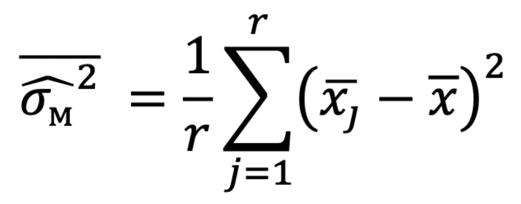

```r
calculate_variance <- function(sample_data, param) {
if (param == "Тип") {
  group_data <- sample_data %>%
    group_by(across(all_of(c("Пол", "Возрастная_группа")))) %>%
    summarise(
      group_size = n(),
      group_variance = var(`Сбер Мегамаркет`, na.rm = TRUE),
      .groups = 'drop'
    )

  weighted_variance <- sum(group_data$group_variance * group_data$group_size, na.rm = TRUE) / sum(group_data$group_size, na.rm = TRUE)

  return(weighted_variance)
} else if (param == "Сер") {
   group_data <- sample_data %>%
   group_by(Станция) %>%
      summarise(group_mean = mean(`Сбер Мегамаркет`, na.rm = TRUE), .groups = 'drop')
      overall_mean <- mean(group_data$group_mean, na.rm = TRUE)
      between_group_variance <- sum((group_data$group_mean - overall_mean)^2 * nrow(group_data)) / nrow(sample_data)
   return(between_group_variance)

  } else {
    return(var(sample_data[['Сбер Мегамаркет']], na.rm = TRUE))
  }
}
```

Подсчёт среднего количества людей на станции

```r
average_people_per_station <- dataset %>%
  group_by(Станция) %>%
  summarise(count = n()) %>%
  summarise(mean_people = mean(count)) %>%
  pull(mean_people)
average_people <- round(52.8169)  # Получаем 53

print(average_people_per_station)
```

```
## [1] 52.8169
```

```r
sample_size <- 600
num_group <- floor(sample_size / 52) + 1
sample_info <- data.frame(
   Отбор = c("Случайный бесповторный", "Случайный повторный", "Механический бесповторный", "Серийная бесповторная", "Серийная повторная", "Типическая бесповторная", "Типическая повторная"),
  Число_элементов = NA,
  Дисперсия = NA
)

random_data <- random_selection_repeat(dataset, sample_size)
sample_info$Число_элементов[1] <- nrow(random_data)
sample_info$Дисперсия[1] <- calculate_variance(random_data, "СлучМех")

sample_info$Число_элементов[2] <- sample_info$Число_элементов[1]
sample_info$Дисперсия[2] <- sample_info$Дисперсия[1]

mechanical_data <- mechanical_selection(dataset, sample_size)
sample_info$Число_элементов[3] <- sample_info$Число_элементов[1]
sample_info$Дисперсия[3] <- sample_info$Дисперсия[1]

serial_data <- serial_selection_repeat(dataset, num_group)
sample_info$Число_элементов[4] <- nrow(serial_data)
sample_info$Дисперсия[4] <- calculate_variance(serial_data, "Сер")

serial_repeat_data <- serial_selection_repeat(dataset, num_group)
sample_info$Число_элементов[5] <- sample_info$Число_элементов[4]
sample_info$Дисперсия[5] <- sample_info$Дисперсия[4]

typical_data <- typical_selection_repeat(dataset, sample_size)
sample_info$Число_элементов[6] <- sample_info$Число_элементов[1]
sample_info$Дисперсия[6] <- sample_info$Дисперсия[1]

typical_repeat_data <- typical_selection_repeat(dataset, sample_size)
sample_info$Число_элементов[7] <- sample_info$Число_элементов[6]
sample_info$Дисперсия[7] <- sample_info$Дисперсия[6]

print(sample_info)
```

```
##                       Отбор Число_элементов   Дисперсия
## 1    Случайный бесповторный             600 363.2039622
## 2       Случайный повторный             600 363.2039622
## 3 Механический бесповторный             600 363.2039622
## 4     Серийная бесповторная             643   0.9878244
## 5        Серийная повторная             643   0.9878244
## 6   Типическая бесповторная             600 363.2039622
## 7      Типическая повторная             600 363.2039622
```

```r
library(dplyr)

calculate_means <- function(dataset) {
  mean_values <- c(
    oz = mean(dataset$`Ozon`, na.rm = TRUE),
    yam = mean(dataset$`Яндекс Маркет`, na.rm = TRUE),
    wb = mean(dataset$`Wildberries`, na.rm = TRUE),
    sber = mean(dataset$`Сбер Мегамаркет`, na.rm = TRUE)
  )
  return(mean_values)
}


random <- c(oz = 0, yam = 0, wb = 0, sber=0)
random_repeat <- c(oz = 0, yam = 0, wb = 0, sber=0)
mechanical <- c(oz = 0, yam = 0, wb = 0, sber=0)
typical <- c(oz = 0, yam = 0, wb = 0, sber=0)
typical_repeat <- c(oz = 0, yam = 0, wb = 0, sber=0)
serial <- c(oz = 0, yam = 0, wb = 0, sber=0)
serial_repeat <- c(oz = 0, yam = 0, wb = 0, sber=0)


for (i in 1:1000) {
random_sample <- random_selection(dataset, sample_size)
random_for_means <- calculate_means(random_sample)
random_repeat_sample <- random_selection_repeat(dataset, sample_size)
random_repeat_for_means <- calculate_means(random_repeat_sample)
mechanical_sample <- mechanical_selection(dataset, sample_size)
mechanical_for_means <- calculate_means(mechanical_sample )
typical_repeat_sample <-typical_selection_repeat(dataset, sample_size)
typical_repeat_for_means <- calculate_means(typical_repeat_sample)
typical_sample <- typical_selection(dataset, sample_size)
typical_for_means <- calculate_means(typical_sample)
serial_repeat_sample <- serial_selection_repeat(dataset, num_group)
serial_repeat_for_means <- calculate_means(serial_repeat_sample)
serial_sample <- serial_selection(dataset, num_group)
serial_for_means <- calculate_means(serial_sample)

random_winner <- names(random_for_means)[which.min(random_for_means)]
random_repeat_winner <- names(random_repeat_for_means)[which.min(random_repeat_for_means)]
mechanical_winner <- names(mechanical_for_means)[which.min(mechanical_for_means)]
typical_winner <- names(typical_for_means)[which.min(typical_for_means)]
typical_repeat_winner <-names(typical_repeat_for_means)[which.min(typical_repeat_for_means)]
serial_winner <- names(serial_for_means)[which.min(serial_for_means)]
serial_repeat_winner <- names(serial_repeat_for_means)[which.min(serial_repeat_for_means)]


random[random_winner] <- random[random_winner] + 1
random_repeat[random_repeat_winner] <- random_repeat[random_repeat_winner] + 1
mechanical[mechanical_winner] <- mechanical[mechanical_winner] + 1
typical[typical_winner] <- typical[typical_winner] + 1
typical_repeat[typical_repeat_winner] <- typical_repeat[typical_repeat_winner] + 1
serial[serial_winner] <- serial[serial_winner] + 1
serial_repeat[serial_repeat_winner] <- serial_repeat[serial_repeat_winner] + 1

}

cat("Результаты случайного бесповторного отбора:\n")
```

```
## Результаты случайного бесповторного отбора:
```

```r
print(random)
```

```
##   oz  yam   wb sber
##   73    0  386  541
```

```r
cat("Результаты случайного повторного отбора:\n")
```

```
## Результаты случайного повторного отбора:
```

```r
print(random_repeat)
```

```
##   oz  yam   wb sber
##   73    0  406  521
```

```r
cat("\nРезультаты механического отбора:\n")
```

```
##
## Результаты механического отбора:
```

```r
print(mechanical)
```

```
##   oz  yam   wb sber
##   86    0  526  388
```

```r
cat("\nРезультаты типического бесповторного отбора:\n")
```

```
##
## Результаты типического бесповторного отбора:
```

```r
print(typical)
```

```
##   oz  yam   wb sber
##  343    0  143  514
```

```r
cat("\nРезультаты типического повторного отбора:\n")
```

```
##
## Результаты типического повторного отбора:
```

```r
print(typical_repeat)
```

```
##   oz  yam   wb sber
##  358    0  111  531
```

```r
cat("\nРезультаты серийного бесповторного отбора:\n")
```

```
##
## Результаты серийного бесповторного отбора:
```

```r
print(serial)
```

```
##   oz  yam   wb sber
##   63    0  403  534
```

```r
cat("\nРезультаты серийного повторного отбора:\n")
```

```
##
## Результаты серийного повторного отбора:
```

```r
print(serial_repeat)
```

```
##   oz  yam   wb sber
##   80    0  369  551
```

```r
head(sample_info)
```

```
##                       Отбор Число_элементов   Дисперсия
## 1    Случайный бесповторный             600 363.2039622
## 2       Случайный повторный             600 363.2039622
## 3 Механический бесповторный             600 363.2039622
## 4     Серийная бесповторная             643   0.9878244
## 5        Серийная повторная             643   0.9878244
## 6   Типическая бесповторная             600 363.2039622
```

```r
alpha <- 0.05
sample_info$Квантиль <- qt(1 - alpha / 2, sample_info$Число_элементов - 1)
head(sample_info)
```

```
##                       Отбор Число_элементов   Дисперсия Квантиль
## 1    Случайный бесповторный             600 363.2039622 1.963932
## 2       Случайный повторный             600 363.2039622 1.963932
## 3 Механический бесповторный             600 363.2039622 1.963932
## 4     Серийная бесповторная             643   0.9878244 1.963666
## 5        Серийная повторная             643   0.9878244 1.963666
## 6   Типическая бесповторная             600 363.2039622 1.963932
```

```r
print(sample_info$Квантиль)
```

```
## [1] 1.963932 1.963932 1.963932 1.963666 1.963666 1.963932 1.963932
```

## Рассчитать предельную ошибку среднего, для каждого метода, на основе полученных в пункте 5) оценок дисперсий.

Предельная ошибка оценивания параметра «генеральной» совокупности (мат. ожидания):

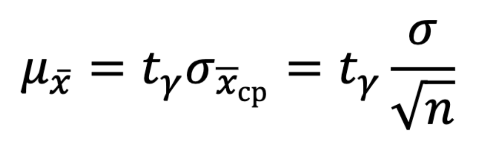

Cлучайный повторный отбор:

[figure not shown]

Механический и случайный бесповторный отбор:

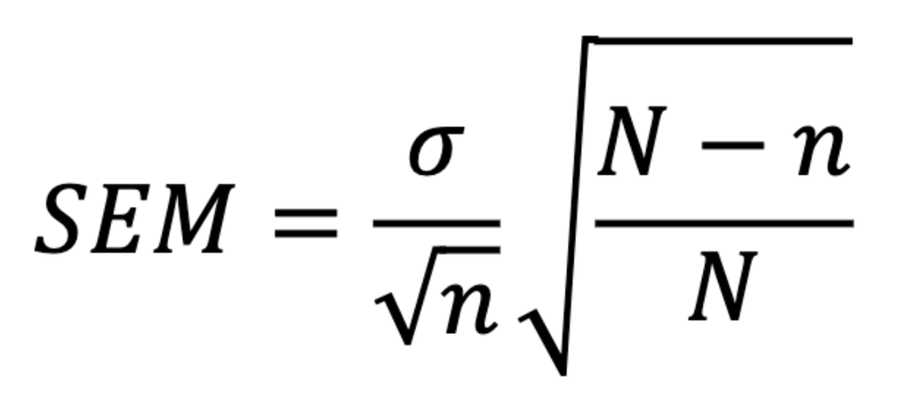

Типический повторный отбор:

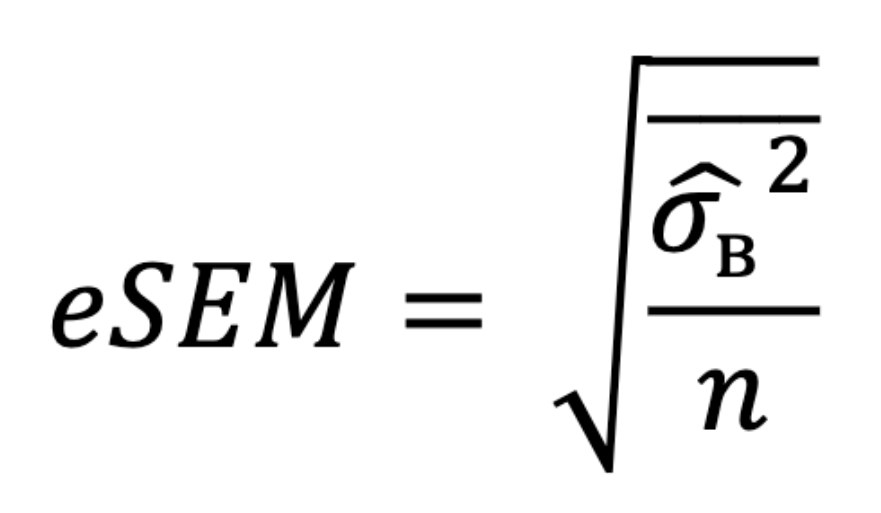

Типический бесповторный отбор:

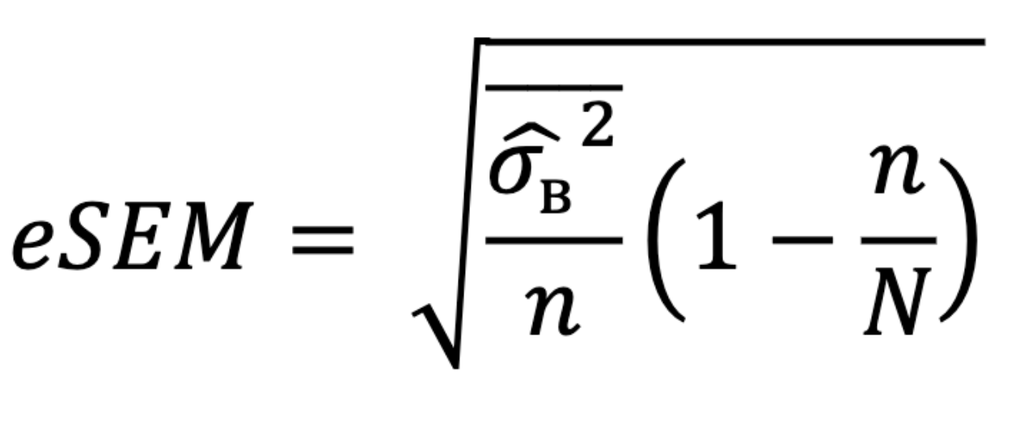

Серийный повторный отбор:

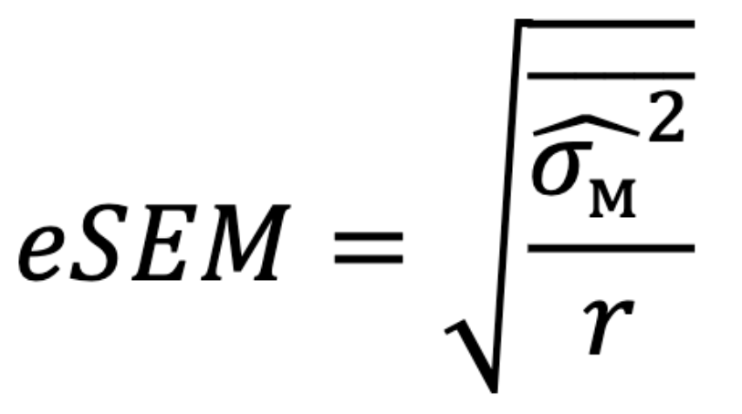

[figure not shown]

Серийный бесповторный отбор:

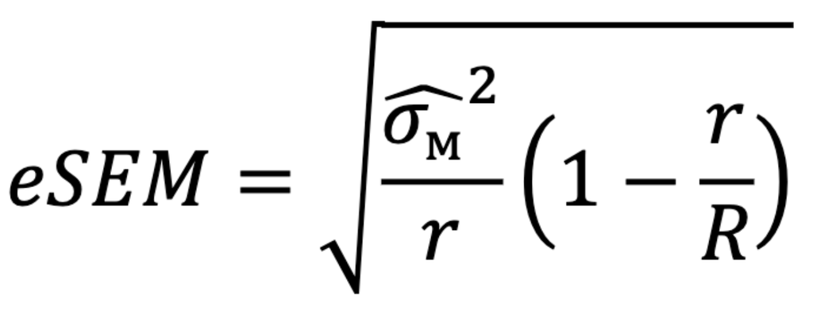

[figure not shown]

```r
sample_info <- sample_info %>%
  mutate(
    mu = case_when(
      Отбор == "Случайный бесповторный" ~ Квантиль * sqrt(Дисперсия / Число_элементов) * sqrt(1 - Число_элементов / nrow(deviations)),
      Отбор == "Случайный повторный" ~ Квантиль * sqrt(Дисперсия / Число_элементов),
      Отбор == "Механический бесповторный" ~ Квантиль * sqrt(Дисперсия / Число_элементов) * sqrt(1 - Число_элементов / nrow(deviations)),
      Отбор == "Серийная бесповторная" ~ Квантиль * sqrt(Дисперсия / num_group) * sqrt(1 - num_group / length(unique(Result$Станция))),
      Отбор == "Серийная повторная" ~ Квантиль * sqrt(Дисперсия / num_group),
      Отбор == "Типическая бесповторная" ~ Квантиль * sqrt(Дисперсия / Число_элементов) * sqrt(1 - Число_элементов / nrow(deviations)),
      Отбор == "Типическая повторная" ~ Квантиль * sqrt(Дисперсия / Число_элементов) ,
      TRUE ~ NA_real_
    )
  )
head(sample_info)
```

```
##                       Отбор Число_элементов   Дисперсия Квантиль        mu
## 1    Случайный бесповторный             600 363.2039622 1.963932 1.4971378
## 2       Случайный повторный             600 363.2039622 1.963932 1.5280099
## 3 Механический бесповторный             600 363.2039622 1.963932 1.4971378
## 4     Серийная бесповторная             643   0.9878244 1.963666 0.5513688
## 5        Серийная повторная             643   0.9878244 1.963666 0.5634000
## 6   Типическая бесповторная             600 363.2039622 1.963932 1.4971378
```

## Полученная Вами оценка предельной ошибки является значительно большей, нежели предельная ошибка генеральной совокупности, для получения эффекта от определения минимального эффективного размера выборки используйте уменьшенное в 2 раза значение оценки предельной ошибки.

```r
sample_info$mu_half <- sample_info$mu / 2
head(sample_info)
```

```
##                       Отбор Число_элементов   Дисперсия Квантиль        mu
## 1    Случайный бесповторный             600 363.2039622 1.963932 1.4971378
## 2       Случайный повторный             600 363.2039622 1.963932 1.5280099
## 3 Механический бесповторный             600 363.2039622 1.963932 1.4971378
## 4     Серийная бесповторная             643   0.9878244 1.963666 0.5513688
## 5        Серийная повторная             643   0.9878244 1.963666 0.5634000
## 6   Типическая бесповторная             600 363.2039622 1.963932 1.4971378
##     mu_half
## 1 0.7485689
## 2 0.7640049
## 3 0.7485689
## 4 0.2756844
## 5 0.2817000
## 6 0.7485689
```

## На основе оценки дисперсии и уменьшенной оценки предельной ошибки определить минимальный объем выборки при заданной в варианте вероятности для 7 типов отбора:

Объём выборки n на основании предельной ошибки оценивания мат.ожидания:

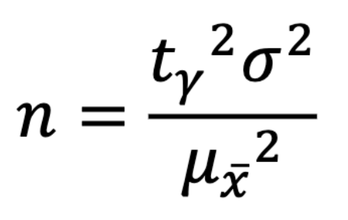

Cлучайный повторный отбор:

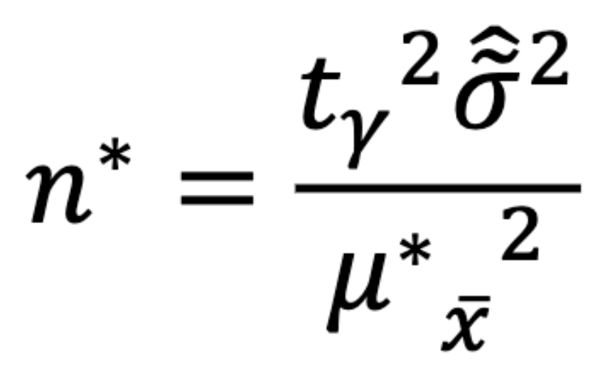

Механический и случайный бесповторный отбор:

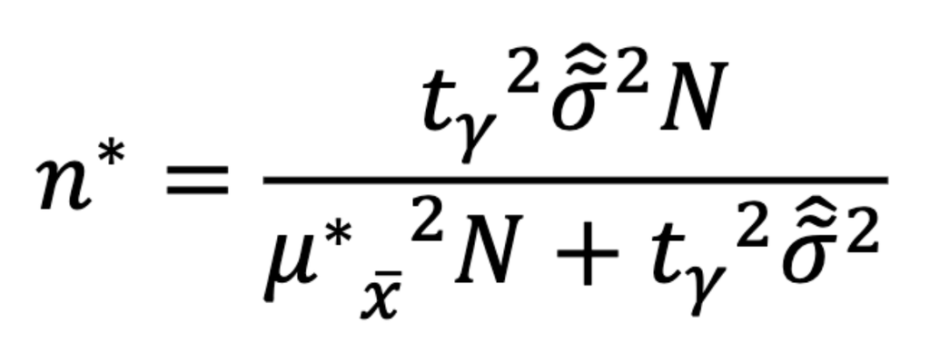

Типический повторный отбор:

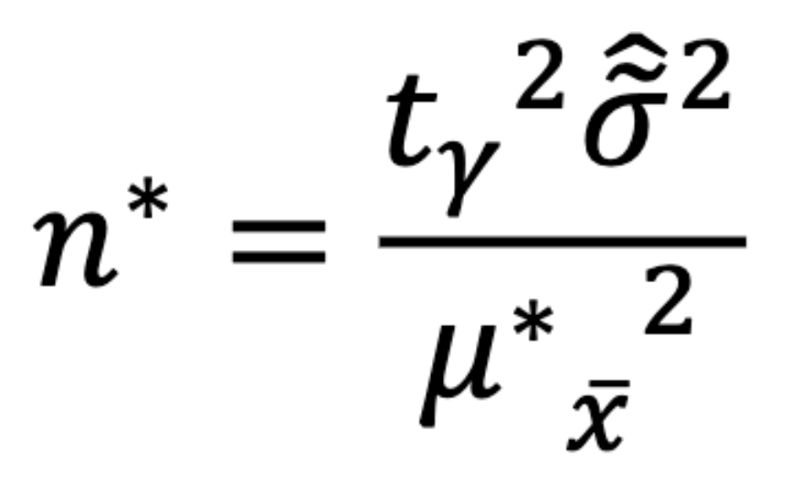

Типический бесповторный отбор:

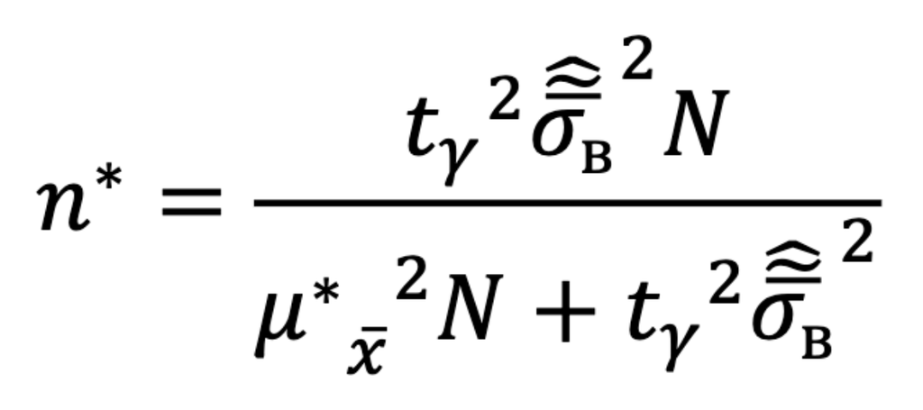

Серийный повторный отбор:

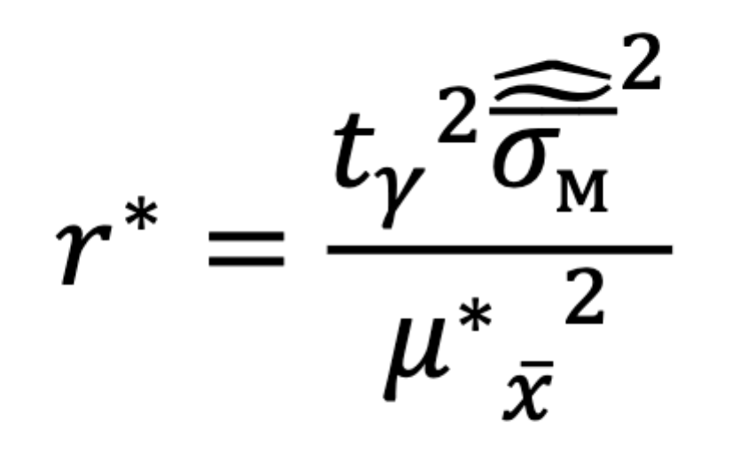

Серийный бесповторный отбор:

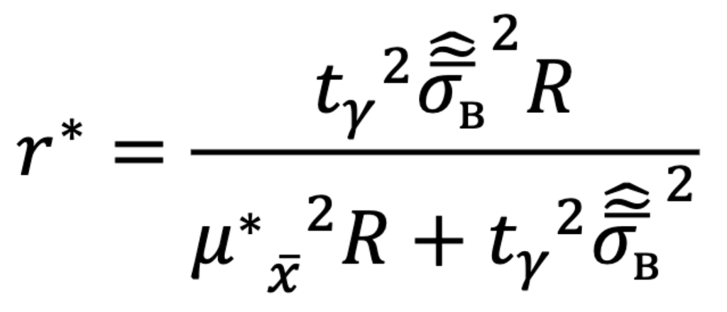

```r
sample_info <- sample_info %>%
  mutate(
    nr_min = case_when(
      Отбор == "Случайный бесповторный" ~ ceiling((Квантиль ^ 2) * Дисперсия * nrow(deviations) / (mu_half ^ 2 * nrow(deviations) + Квантиль ^ 2 * Дисперсия)),
      Отбор == "Случайный повторный" ~ ceiling((Квантиль ^ 2) * Дисперсия / mu_half ^ 2),
      Отбор == "Механический бесповторный" ~ ceiling((Квантиль ^ 2) * Дисперсия * nrow(deviations) / (mu_half ^ 2 * nrow(deviations) + Квантиль ^ 2 * Дисперсия)),
      Отбор == "Серийная бесповторная" ~ ceiling((Квантиль ^ 2) * length(unique(Result$Станция)) * Дисперсия / ((mu_half ^ 2) * length(unique(Result$Станция)) + Дисперсия * (Квантиль ^ 2))),
      Отбор == "Серийная повторная" ~ ceiling((Квантиль ^ 2) * Дисперсия / (mu_half ^ 2)),
      Отбор == "Типическая бесповторная" ~ ceiling((Квантиль ^ 2) * nrow(deviations) * Дисперсия / ((mu_half ^ 2) * nrow(deviations) + Дисперсия * (Квантиль ^ 2))),
      Отбор == "Типическая повторная" ~ ceiling((Квантиль ^ 2) * Дисперсия / (mu_half ^ 2)),
      TRUE ~ NA_real_
    )
  )
head(sample_info)
```

```
##                       Отбор Число_элементов   Дисперсия Квантиль        mu
## 1    Случайный бесповторный             600 363.2039622 1.963932 1.4971378
## 2       Случайный повторный             600 363.2039622 1.963932 1.5280099
## 3 Механический бесповторный             600 363.2039622 1.963932 1.4971378
## 4     Серийная бесповторная             643   0.9878244 1.963666 0.5513688
## 5        Серийная повторная             643   0.9878244 1.963666 0.5634000
## 6   Типическая бесповторная             600 363.2039622 1.963932 1.4971378
##     mu_half nr_min
## 1 0.7485689   2143
## 2 0.7640049   2400
## 3 0.7485689   2143
## 4 0.2756844     43
## 5 0.2817000     48
## 6 0.7485689   2143
```

## Использовать каждый способ отбора не менее 1000 раз (для механического сдвигать точку старта). Для каждой полученной выборки определить, какая из альтернатив оказывается наиболее близкой к пользовательским ожиданиям. Получить усреднённые по всем выборам оценки альтернатив для всех способов отбора

```r
library(dplyr)

calculate_variance_serial_full <- function(sample_data) {
  total_variance <- var(sample_data[['Сбер Мегамаркет']], na.rm = TRUE)
  return(total_variance)
}

random <- c(oz = 0, yam = 0, wb = 0, sber=0)
random_repeat <- c(oz = 0, yam = 0, wb = 0, sber=0)
mechanical <- c(oz = 0, yam = 0, wb = 0, sber=0)
typical <- c(oz = 0, yam = 0, wb = 0, sber=0)
typical_repeat <- c(oz = 0, yam = 0, wb = 0, sber=0)
serial <- c(oz = 0, yam = 0, wb = 0, sber=0)
serial_repeat <- c(oz = 0, yam = 0, wb = 0, sber=0)

random_mean_mean <- c(oz = 0, yam = 0, wb = 0, sber=0)
random_repeat_mean_mean <- c(oz = 0, yam = 0, wb = 0, sber=0)
mechanical_mean_mean <- c(oz = 0, yam = 0, wb = 0, sber=0)
typical_mean_mean <- c(oz = 0, yam = 0, wb = 0, sber=0)
typical_repeat_mean_mean <- c(oz = 0, yam = 0, wb = 0, sber=0)
serial_mean_mean <- c(oz = 0, yam = 0, wb = 0, sber=0)
serial_repeat_mean_mean <- c(oz = 0, yam = 0, wb = 0, sber=0)

random_mean_mean <- list(oz = c(), yam = c(), wb = c(), sber = c())
random_repeat_mean_mean <- list(oz = c(), yam = c(), wb = c(), sber = c())
mechanical_mean_mean <- list(oz = c(), yam = c(), wb = c(), sber = c())
typical_mean_mean <- list(oz = c(), yam = c(), wb = c(), sber = c())
typical_repeat_mean_mean <- list(oz = c(), yam = c(), wb = c(), sber = c())
serial_mean_mean <- list(oz = c(), yam = c(), wb = c(), sber = c())
serial_repeat_mean_mean <- list(oz = c(), yam = c(), wb = c(), sber = c())

variance_results <- list(
  random = numeric(1000),
  random_repeat = numeric(1000),
  mechanical = numeric(1000),
  typical = numeric(1000),
  typical_repeat = numeric(1000),
  serial = numeric(1000),
  serial_repeat = numeric(1000),
  serial_full = numeric(1000),
  serial_full_repeat = numeric(1000)
)

for (i in 1:1000) {
  random_sample <- random_selection(dataset, sample_info$nr_min[1])
  random_for_means <- calculate_means(random_sample)
  random_mean_mean <- Map(c, random_mean_mean, random_for_means)

  random_repeat_sample <- random_selection_repeat(dataset, sample_info$nr_min[2])
  random_repeat_for_means <- calculate_means(random_repeat_sample)
  random_repeat_mean_mean <- Map(c, random_repeat_mean_mean, random_repeat_for_means)

  mechanical_sample <- mechanical_selection(dataset, sample_info$nr_min[3])
  mechanical_for_means <- calculate_means(mechanical_sample)
  mechanical_mean_mean <- Map(c, mechanical_mean_mean, mechanical_for_means)

  typical_sample <- typical_selection(dataset, sample_info$nr_min[6])
  typical_for_means <- calculate_means(typical_sample)
  typical_mean_mean <- Map(c, typical_mean_mean, typical_for_means)

  typical_repeat_sample <- typical_selection_repeat(dataset, sample_info$nr_min[7])
  typical_repeat_for_means <- calculate_means(typical_repeat_sample)
  typical_repeat_mean_mean <- Map(c, typical_repeat_mean_mean, typical_repeat_for_means)

  serial_sample <- serial_selection(dataset, sample_info$nr_min[4])
  serial_for_means <- calculate_means(serial_sample)
  serial_mean_mean <- Map(c, serial_mean_mean, serial_for_means)

  serial_repeat_sample <- serial_selection_repeat(dataset, sample_info$nr_min[5])
  serial_repeat_for_means <- calculate_means(serial_repeat_sample)
  serial_repeat_mean_mean <- Map(c, serial_repeat_mean_mean, serial_repeat_for_means)

random_winner <- names(random_for_means)[which.min(random_for_means)]
random_repeat_winner <- names(random_repeat_for_means)[which.min(random_repeat_for_means)]
mechanical_winner <- names(mechanical_for_means)[which.min(mechanical_for_means)]
typical_winner <- names(typical_for_means)[which.min(typical_for_means)]
typical_repeat_winner <-names(typical_repeat_for_means)[which.min(typical_repeat_for_means)]
serial_winner <- names(serial_for_means)[which.min(serial_for_means)]
serial_repeat_winner <- names(serial_repeat_for_means)[which.min(serial_repeat_for_means)]
random[random_winner] <- random[random_winner] + 1
random_repeat[random_repeat_winner] <- random_repeat[random_repeat_winner] + 1
mechanical[mechanical_winner] <- mechanical[mechanical_winner] + 1
typical[typical_winner] <- typical[typical_winner] + 1
typical_repeat[typical_repeat_winner] <- typical_repeat[typical_repeat_winner] + 1
serial[serial_winner] <- serial[serial_winner] + 1
serial_repeat[serial_repeat_winner] <- serial_repeat[serial_repeat_winner] + 1



variance_results$random[i] <- calculate_variance(random_sample, 'СлучМех')
  variance_results$random_repeat[i] <- calculate_variance(random_repeat_sample, 'СлучМех')
  variance_results$mechanical[i] <- calculate_variance(mechanical_sample,'СлучМех')
  variance_results$typical[i] <- calculate_variance(typical_sample , 'Тип')
  variance_results$typical_repeat[i] <- calculate_variance(typical_repeat_sample, "Тип")
  variance_results$serial[i] <- calculate_variance(serial_sample, "Сер")
  variance_results$serial_repeat[i] <- calculate_variance(serial_repeat_sample, "Сер")
  variance_results$serial_full[i] <- calculate_variance_serial_full(serial_sample)
  variance_results$serial_full_repeat[i] <- calculate_variance_serial_full(serial_repeat_sample)
}

# Выводим результаты
cat("Результаты случайного бесповторного отбора:\n")
```

```
## Результаты случайного бесповторного отбора:
```

```r
print(random)
```

```
##   oz  yam   wb sber
##   10    0  326  664
```

```r
cat("Результаты случайного повторного отбора:\n")
```

```
## Результаты случайного повторного отбора:
```

```r
print(random_repeat)
```

```
##   oz  yam   wb sber
##    4    0  349  647
```

```r
cat("\nРезультаты механического отбора:\n")
```

```
##
## Результаты механического отбора:
```

```r
print(mechanical)
```

```
##   oz  yam   wb sber
##    0    0  350  650
```

```r
cat("\nРезультаты типического бесповторного отбора:\n")
```

```
##
## Результаты типического бесповторного отбора:
```

```r
print(typical)
```

```
##   oz  yam   wb sber
##  133    0   30  837
```

```r
cat("\nРезультаты типического повторного отбора:\n")
```

```
##
## Результаты типического повторного отбора:
```

```r
print(typical_repeat)
```

```
##   oz  yam   wb sber
##  104    0   19  877
```

```r
cat("\nРезультаты серийного бесповторного отбора:\n")
```

```
##
## Результаты серийного бесповторного отбора:
```

```r
print(serial)
```

```
##   oz  yam   wb sber
##   10    0  323  667
```

```r
cat("\nРезультаты серийного повторного отбора:\n")
```

```
##
## Результаты серийного повторного отбора:
```

```r
print(serial_repeat)
```

```
##   oz  yam   wb sber
##   10    0  313  677
```

```r
random_mean_avg <- sapply(random_mean_mean, mean)
random_repeat_mean_avg <- sapply(random_repeat_mean_mean, mean)
mechanical_mean_avg <- sapply(mechanical_mean_mean, mean)
typical_mean_avg <- sapply(typical_mean_mean, mean)
typical_repeat_mean_avg <- sapply(typical_repeat_mean_mean, mean)
serial_mean_avg <- sapply(serial_mean_mean, mean)
serial_repeat_mean_avg <- sapply(serial_repeat_mean_mean, mean)


random_mean_var <- sapply(random_mean_mean, var)
random_repeat_mean_var <- sapply(random_repeat_mean_mean, var)
mechanical_mean_var <- sapply(mechanical_mean_mean, var)
typical_mean_var <- sapply(typical_mean_mean, var)
typical_repeat_mean_var <- sapply(typical_repeat_mean_mean, var)
serial_mean_var <- sapply(serial_mean_mean, var)
serial_repeat_var <- sapply(serial_repeat_mean_mean, var)

print(list(
  random_mean_avg = random_mean_avg,
  random_repeat_mean_avg = random_repeat_mean_avg,
  mechanical_mean_avg = mechanical_mean_avg,
  typical_mean_avg = typical_mean_avg,
  typical_repeat_mean_avg = typical_repeat_mean_avg,
  serial_mean_avg = serial_mean_avg,
  serial_repeat_mean_avg = serial_repeat_mean_avg
))
```

```
## $random_mean_avg
##       oz      yam       wb     sber
## 46.49316 53.42957 45.78050 45.57744
##
## $random_repeat_mean_avg
##       oz      yam       wb     sber
## 46.49261 53.42528 45.73767 45.55960
##
## $mechanical_mean_avg
##       oz      yam       wb     sber
## 46.14704 53.09460 45.42756 45.41674
##
## $typical_mean_avg
##       oz      yam       wb     sber
## 47.14739 54.36499 47.41804 46.70274
##
## $typical_repeat_mean_avg
##       oz      yam       wb     sber
## 47.12897 54.32332 47.37465 46.63525
##
## $serial_mean_avg
##       oz      yam       wb     sber
## 46.50695 53.43958 45.76172 45.55480
##
## $serial_repeat_mean_avg
##       oz      yam       wb     sber
## 46.47823 53.42428 45.76932 45.57344
```

```r
print(' ')
```

```
## [1] " "
```

```r
print(list(
  random_mean_var = random_mean_avg,
  random_repeat_mean_var = random_repeat_mean_avg,
  mechanical_mean_var = mechanical_mean_avg,
  typical_mean_var = typical_mean_avg,
  typical_repeat_mean_var = typical_repeat_mean_avg,
  serial_mean_var = serial_mean_avg,
  serial_repeat_mean_var = serial_repeat_mean_avg
))
```

```
## $random_mean_var
##       oz      yam       wb     sber
## 46.49316 53.42957 45.78050 45.57744
##
## $random_repeat_mean_var
##       oz      yam       wb     sber
## 46.49261 53.42528 45.73767 45.55960
##
## $mechanical_mean_var
##       oz      yam       wb     sber
## 46.14704 53.09460 45.42756 45.41674
##
## $typical_mean_var
##       oz      yam       wb     sber
## 47.14739 54.36499 47.41804 46.70274
##
## $typical_repeat_mean_var
##       oz      yam       wb     sber
## 47.12897 54.32332 47.37465 46.63525
##
## $serial_mean_var
##       oz      yam       wb     sber
## 46.50695 53.43958 45.76172 45.55480
##
## $serial_repeat_mean_var
##       oz      yam       wb     sber
## 46.47823 53.42428 45.76932 45.57344
```

```r
cat("\nСредняя дисперсия случайного бесповторного отбора: ", mean(variance_results$random))
```

```
##
## Средняя дисперсия случайного бесповторного отбора:  338.7877
```

```r
cat("\nСредняя дисперсия случайного повторного отбора: ", mean(variance_results$random_repeat))
```

```
##
## Средняя дисперсия случайного повторного отбора:  338.7258
```

```r
cat("\nСредняя дисперсия маханического отбора: ", mean(variance_results$mechanical))
```

```
##
## Средняя дисперсия маханического отбора:  333.5737
```

```r
cat("\nСредняя дисперсия типического бесповторного отбора: ", mean(variance_results$typical))
```

```
##
## Средняя дисперсия типического бесповторного отбора:  293.3681
```

```r
cat("\nСредняя дисперсия типического повторного отбора: ", mean(variance_results$typical_repeat))
```

```
##
## Средняя дисперсия типического повторного отбора:  292.8177
```

```r
cat("\nСредняя межгрупповая дисперсия серийного бесповторного отбора: ", mean(variance_results$serial))
```

```
##
## Средняя межгрупповая дисперсия серийного бесповторного отбора:  5.353839
```

```r
cat("\nСредняя межгрупповая дисперсия серийного повторного отбора: ", mean(variance_results$serial_repeat))
```

```
##
## Средняя межгрупповая дисперсия серийного повторного отбора:  5.595334
```

```r
cat("\nСредняя дисперсия серийного бесповторного отбора: ", mean(variance_results$serial_full))
```

```
##
## Средняя дисперсия серийного бесповторного отбора:  338.1765
```

```r
cat("\nСредняя дисперсия серийного повторного отбора: ", mean(variance_results$serial_full_repeat))
```

```
##
## Средняя дисперсия серийного повторного отбора:  337.971
```

### Сопоставить эти оценки со значениями показателей рассчитанных по данным генеральной совокупности. Сделать вывод о точности и надежности методов отбора.

Сравним с показателями “генеральной” совокупности. Выведем её

```r
head(stat)
```

```
##                         Ozon Яндекс Маркет Wildberries Сбер Мегамаркет
## Выборочное среднее  46.49660       53.4336    45.75400        45.56547
## Медиана             45.00000       52.0000    43.00000        44.00000
## Мода                46.00000       49.0000    36.00000        41.00000
## Усеченное среднее   45.96881       52.8600    44.97504        44.83430
## Дисперсия          293.79451      369.8289   361.50012       338.20533
```

## Вывод:

Не прослеживается значительная зависимость между тем, повторный отбор или бесповторный отбор, и его надежностью/достоверностью. Результаты для этих методов различаются несущественно, особенно для случайного и серийного отборов.

Во всех остальных способах отбора подтверждается победитель “генеральной” совокупности - Сбер Мегамаркет. Этот бренд стабильно набирает больше побед, особенно в типическом отборе, что подтверждает его устойчивую конкурентоспособность.При отборе с учетом $n^*$ и $r^*$ истинный победитель (Сбер Мегамаркет) набирает больше побед, чем при случайном отборе 4% генеральной совокупности. Это доказывает важность оптимального размера выборки для повышения точности результатов.

Дисперсия победителя (Сбер Мегамаркет) для видов отбора и генеральной совокупности схожа во всех типах отбора, кроме типического. Типический отбор показал наименьшую дисперсию, что свидетельствует о его стабильности, но может приводить к завышению средних значений для некоторых групп.